# Descriptive Analysis of Erdinç Taşel

## Erdinç Taşel (Data Analyst)

#### Eligible to work full time in the Netherland

erdinctasel@gmail.com | Eindhoven

- https://www.linkedin.com/in/erdinctasel/
- https://github.com/erdinctasel

#### My CV

```python
%matplotlib inline
#%pip install seaborn
import pandas as pd
import numpy as np
import seaborn as sns                       #visualisation
import matplotlib as mpl
import matplotlib.pyplot as plt             #visualisation
mpl.style.use("default")
import matplotlib.dates as mdates
from datetime import datetime
```

```python
%%capture
%pip install folium
import folium
from folium import plugins
```

```python
map_eind=folium.Map(location=[51.4381, 5.4752], zoom_start=4)
from folium.plugins import Geocoder

Geocoder().add_to(map_eind)
incidents = folium.map.FeatureGroup()
folium.Marker(location=[51.4381, 5.4752], popup="Where I am living").add_to(incidents)
#folium.features.CircleMarker(
#            [51.4381, 5.4752],
#            tooltip="Where I am living",
#            radius=15, # define how big you want the circle markers to be
#            color='yellow',
#            fill=True,
#            fill_color='blue',
#            fill_opacity=0.6
#        ).add_to(incidents)
folium.features.CircleMarker(
            [39.891388, 32.784721],
            tooltip="Where I was graduated",
            radius=15, # define how big you want the circle markers to be
            color='yellow',
            fill=True,
            fill_color='blue',
            fill_opacity=0.6
        ).add_to(incidents)

# add incidents to map
minimap = plugins.MiniMap()
map_eind.add_child(minimap)

map_eind.add_child(incidents)
```

Make this Notebook Trusted to load map: File -> Trust Notebook

[interactive chart not shown]

## Professional Experiences

#### PostNL, Postbezorgers, 10.2023 - present

- Post delivery

#### Freelance & Voluntarily Works, 09.2021 - present

- Data analyses of Sea Turtles nesting activities in Fethiye Area by coding in Python and using libraries (Numpy, Pandas and Seaborn) cooperating with specialist in Ministry of Environment of Turkish Republic,
- Internal project, descriptive data analysis, visualization and dashboard of home expenses in the Netherlands by coding in Python and using libraries (Pandas, Seaborn, Plotly and Dash) https://erdinctasel.github.io/Bank_account_analyses_ABN_ING.html
- Bike maintenance and repairing,
- Library Officer, volunteer at the library of 't Slingertouw Basisschool Library,
- Volunteer at the organizations in 't Slingertouw Basisschool,
- Taking online courses from Coursera, Udemy and EdX about Data Science & Data Analyst, Coursera about Data Science, Analyst,
- Taking elementary Dutch course from STE,

#### Verigo Digital Engineering Inc., Geospatial Data Analyst, 05.2020 – 11.2020

- Defining geospatial data requirements, data collection and preparation by extracting, cleaning and transforming for reproduction of Sea Turtles to ensure data integrity and consistency,
- Analyzing by deciding on leading attributes and determining reproduction of Sea Turtles success rate, generating map views and preparing project reports,
- Generating the vector data of power lines cables in Italy by post-processing of 1080 LiDAR files,

#### Middle East Technical University, Department of Environmental Eng., GIS Data Analyst, 03.2001 – 12.2001

- Creating raster and vector data for the Marmara Region Environmental Emergency Action Plan and preparing map views,

#### Başarsoft Information Technologies Inc., GIS Data Analyst 01.2001 – 05.2001

- Developing applications on MapINFO Software with MapBasic scripting language,
- Giving consultancy to public/private companies about GIS applications, MapINFO software and its extensions,

## Education

- MSc degree in GIS, Geodetic and Geographic Information Technologies (GGIT) Department, 09.2000 - 11.2003, Middle East Technical University,
- B.S. degree in Environmental Engineering, 09.1994 – 06.2000, Middle East Technical University,
  - 1994-1995 English Prep School,

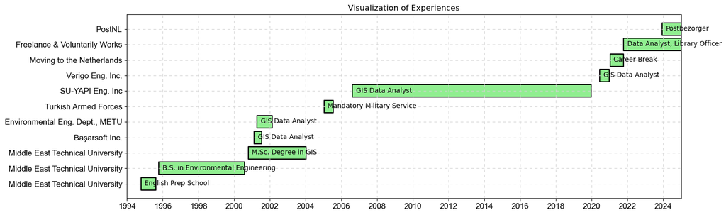

```python
source = pd.read_csv(r"D:\00_BACKUP_BY_DRIVE\cv\erdinc.csv")
font = {'family': 'arial',
        'color':  'black',
        'weight': 'normal',
        'size': 12,
        }

source['start'] = pd.to_datetime(source['start'],yearfirst=True,format="%Y-%m-%d")
source['end'] = pd.to_datetime(source['end'],yearfirst=True,format="%Y-%m-%d")
source['diff'] = source['end'] - source['start']

# Declaring a figure "gnt"
fig, ax = plt.subplots(figsize=(15,5))

ax.autoscale()
ax.set(title="Visualization of Experiences")
# Need to fix hidden tick labels
# https://stackoverflow.com/questions/43673659/matplotlib-not-showing-first-label-on-x-axis-for-the-bar-plot
source= source.sort_values(by='start').reset_index(drop=True).reset_index()
ax.set_xlim(xmin=1994, xmax=2025)
plt.xticks(np.arange(1994, 2025, 2))
ax.set_xticklabels(labels= np.arange(1994, 2025, 2),fontdict=font)
y_tick_labels = source.experience.values
y_pos = np.arange(len(y_tick_labels))



ax.set_yticks(y_pos)
ax.set_yticklabels(y_tick_labels, fontdict=font)
ax.grid(True, color="lightgrey",dashes=(5,5))

for index, row in source.iterrows():
    start_year = int(row.start.strftime("%Y"))+int(row.start.strftime("%m"))/12 + int(row.start.strftime("%d"))/30
    duration = row['diff'].days/365
    ax.broken_barh([(start_year, duration)],
                    (index-0.4,0.8),
                    facecolors ='lightgreen',
                    edgecolors = "black",
                    linewidth = 1.5,
                    label=row.position
                  )
    ax.text(start_year+ 0.2, index-0.1, row.position)
plt.savefig("timeline.jpg")
```

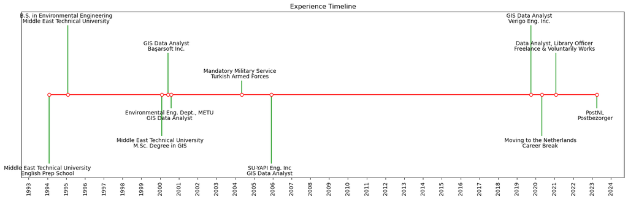

```python
source = pd.read_csv(r"D:\00_BACKUP_BY_DRIVE\cv\erdinc.csv")


source['start'] = pd.to_datetime(source['start'],yearfirst=True,format="%Y-%m-%d")
source['end'] = pd.to_datetime(source['end'],yearfirst=True,format="%Y-%m-%d")
source['diff'] = source['end'] - source['start']
source= source.sort_values(by='start').reset_index(drop=True)
dates_start=source["start"]
xp= source["experience"]
position= source["position"]

# Choose some nice levels
levels = np.tile([-5, 5, -3, 3, -1, 1],
                 int(np.ceil(len(dates_start)/6)))[:len(dates_start)]

# Create figure and plot a stem plot with the date
fig, ax = plt.subplots(figsize=(16, 5), layout="constrained")
ax.set(title="Experience Timeline")

ax.vlines(dates_start, 0, levels, color="tab:green")  # The vertical stems.
ax.plot(dates_start, np.zeros_like(dates_start), "-o",
        color="r", markerfacecolor="w")  # Baseline and markers on it.


# annotate lines
for d, l, x in zip(dates_start, levels, xp):
    ax.annotate(x, xy=(d, l),
                xytext=(-3, np.sign(l)*3), textcoords="offset points",
                horizontalalignment="center",
                verticalalignment="bottom" if l > 0 else "top")

for d, l, p in zip(dates_start, levels, position):
    ax.annotate(p, xy=(d, l),
                xytext=(-3, np.sign(l)*13), textcoords="offset points",
                horizontalalignment="center",
                verticalalignment="top" if l < 0 else "bottom")

# format x-axis with 12-month intervals
ax.xaxis.set_major_locator(mdates.YearLocator(1,8,1))
ax.xaxis.set_major_formatter(mdates.DateFormatter("%Y"))
#ax.xaxis.set_minor_locator(mdates.MonthLocator(interval=6))
#ax.xaxis.set_minor_formatter(mdates.DateFormatter("%b"))

plt.setp(ax.get_xticklabels(which="both"), rotation=90, ha="center")

# remove y-axis and spines
ax.yaxis.set_visible(False)
#ax.spines[["left", "top", "right"]].set_visible(False)

ax.margins(y=0.1)
plt.show()
```

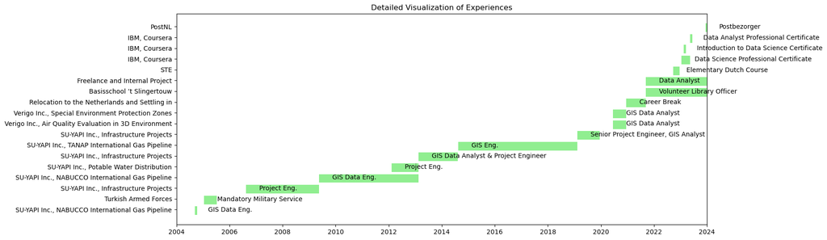

```python
source = pd.read_csv(r"D:\00_BACKUP_BY_DRIVE\cv\erdinc_detail.csv")


source['start'] = pd.to_datetime(source['start'],yearfirst=True,format="%Y-%m-%d")
source['end'] = pd.to_datetime(source['end'],yearfirst=True,format="%Y-%m-%d")
source['diff'] = source['end'] - source['start']

# Declaring a figure "gnt"
fig, ax = plt.subplots(figsize=(15,6))

#ax.autoscale()
ax.set(title="Detailed Visualization of Experiences")
# Need to fix hidden tick labels
# https://stackoverflow.com/questions/43673659/matplotlib-not-showing-first-label-on-x-axis-for-the-bar-plot
source= source.sort_values(by='start').reset_index(drop=True).reset_index()

ax.set_xlim(xmin=2004, xmax=2024)

plt.xticks(np.arange(2004, 2025, 2))

y_tick_labels = source.experience.values
y_pos = np.arange(len(y_tick_labels))

ax.set_yticks(y_pos)
ax.set_yticklabels(y_tick_labels)

for index, row in source.iterrows():
    start_year = int(row.start.strftime("%Y"))+int(row.start.strftime("%m"))/12 + int(row.start.strftime("%d"))/30
    duration = row['diff'].days/365
    ax.broken_barh([(start_year, duration)],
                    (index-0.5,0.8),
                    facecolors =('lightgreen'),
                    label=row.position
                  )
    ax.text(start_year+0.5, index-0.2, row.position)
```

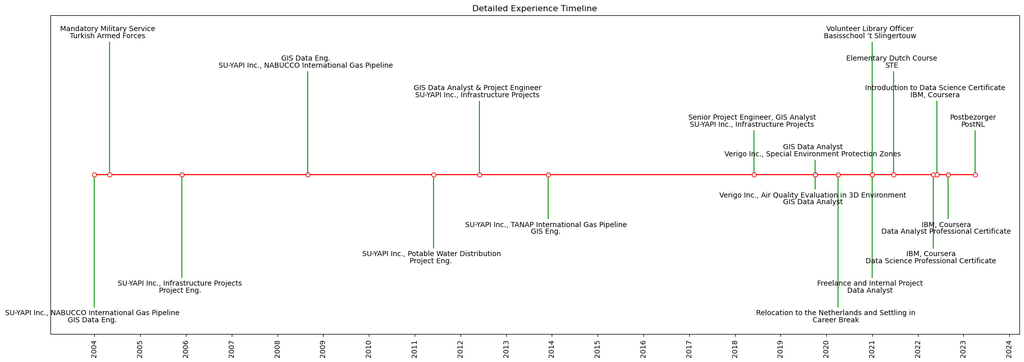

```python
source = pd.read_csv(r"D:\00_BACKUP_BY_DRIVE\cv\erdinc_detail.csv")


source['start'] = pd.to_datetime(source['start'],yearfirst=True,format="%Y-%m-%d")
source['end'] = pd.to_datetime(source['end'],yearfirst=True,format="%Y-%m-%d")
source['diff'] = source['end'] - source['start']
source= source.sort_values(by='start').reset_index(drop=True)
dates_start=source["start"]
xp= source["experience"]
position= source["position"]

# Choose some nice levels
levels = np.tile([-9,9,-7, 7, -5, 5, -3, 3, -1, 1],
                 int(np.ceil(len(dates_start)/6)))[:len(dates_start)]

# Create figure and plot a stem plot with the date
fig, ax = plt.subplots(figsize=(20, 7), layout="constrained")
ax.set(title="Detailed Experience Timeline")

ax.vlines(dates_start, 0, levels, color="tab:green")  # The vertical stems.
ax.plot(dates_start, np.zeros_like(dates_start), "-o",
        color="r", markerfacecolor="w")  # Baseline and markers on it.


# annotate lines
for d, l, x in zip(dates_start, levels, xp):
    ax.annotate(x, xy=(d, l),
                xytext=(-3, np.sign(l)*3), textcoords="offset points",
                horizontalalignment="center",
                verticalalignment="bottom" if l > 0 else "top")

for d, l, p in zip(dates_start, levels, position):
    ax.annotate(p, xy=(d, l),
                xytext=(-3, np.sign(l)*13), textcoords="offset points",
                horizontalalignment="center",
                verticalalignment="top" if l < 0 else "bottom")

# format x-axis with 12-month intervals
ax.xaxis.set_major_locator(mdates.YearLocator(1,8,1))
ax.xaxis.set_major_formatter(mdates.DateFormatter("%Y"))
#ax.xaxis.set_minor_locator(mdates.MonthLocator(interval=6))
#ax.xaxis.set_minor_formatter(mdates.DateFormatter("%Y"))

plt.setp(ax.get_xticklabels(which="both"), rotation=90, ha="center")

# remove y-axis and spines
ax.yaxis.set_visible(False)
#ax.spines[["left", "top", "right"]].set_visible(False)

ax.margins(y=0.1)
plt.show()
```

## Skills

#### Language

- English, Professional working proficiency,
- Dutch, Elementary,
- Turkish- Native proficiency,

#### Computer

- Data Analyses: Python, SQL, Data Analyzing Libraries (Pandas, Numpy, Seaborn, Plotly, Dash), PostgreSQL, SQLite, Microsoft Power BI, IBM Cognos, Anaconda, JupyterLab, Visual Studio Code
- Geospatial Data Analyses: ESRI ArcGIS, QGIS Desktop, Global Mapper, Microstation, AutoCAD,
- Other: Microsoft Office, Libreoffice,

#### Job-Related

- Data Conversion,
- ETL (Extract, Transform, Load) Process,
- Data Visualization, Dashboard,
- Machine Learning,
- Statistics,
- Statistical and BI (Business Intelligence) Tools,

#### Personal

- Planning and Organizing Ability,
- Analytical Thinking,
- Problem Solving,
- Eager to learn & open-minded,
- Self-motivated,

## Certifications & Courses

- IBM Data Analyst Professional Certificate, Coursera, KP26PLU3ZCXG https://coursera.org/share/c040b1d82c69eb8bdce63382cf279412
  - Introduction to Data Analytics
  - Excel Basics for Data Analysis
  - Data Visualization and Dashboards with Excel and Cognos
  - Python for Data Science, AI & Development
  - Python Project for Data Science
  - Databases and SQL for Data Science with Python
  - Data Analysis with Python
  - Data Visualization with Python
  - IBM Data Analyst Capstone Project
- IBM Data Science Professional Certificate, Coursera, RCFZ98CCSVQT https://coursera.org/share/f0c62ba49b34f3c0bb4c27c873531ed6
  - Applied Data Science Capstone, 04.2023
  - Machine Learning with Python, 03.2023
  - Data Visualization with Python, 03.2023
  - Data Analysis with Python, 03.2023
  - Databases and SQL for Data Science with Python, 02.2023
  - Python Project for Data Science, 01.2023
  - Python for Data Science, AI & Development, 01.2023
  - Data Science Methodology, 01.2023
  - Tools for Data Science, 01. 2023
  - What is Data Science, 01.2023
- Introduction to Data Science Specialization, IBM, Coursera, 24GUS4SKVDW7
  - What is Data Science, 01.2023
  - Tools for Data Science, 01. 2023
  - Data Science Methodology, 01.2023
  - Databases and SQL for Data Science with Python, 02.2023
- Statistics for Data Science and Business Analysis, Udemy
- Python A-Z™: Data Science and Machine Learning, Udemy
- Python for Everyone, ESRI
- Introduction to Spatial Databases with PostGIS and QGIS 3.0, Udemy
- QGIS 3.0 for GIS Professionals, Udemy

## Interests

- Orienteering (not same as geocaching) sport,
  - Orienteering mapper, middle, long, sprint and relay course planner,
  - Event director and advisor of ODTÜ OPEN Multi Day Orienteering Event Organization (http://www.odtuopen.org), 2005 - 2016
  - METU Orienteering and Navigation Team co-founder, team leader, technical trainer, consultant and licensed athlete, 2000 – 2021,
  - CONDES Orienteering Course Planning Software beta tester and Turkish translator, 2014 – present (https://condes.net/),
- Playing classical pieces with classical guitar,
- Sudoku.